# PRACTICA_DBEAVER_RAQUEL

```python
# PRACTICA DBEAVER RAQUEL

! pip install --quiet sqlalchemy
```

```python
! pip install --quiet psycopg2-binary
```

```python
! pip install --quiet plotly
```

```python
# bases de datos
from sqlalchemy import create_engine
```

```python
# para el análisis de datos
import pandas as pd
import numpy as np
import random as rnd
from datetime import datetime


# visualización
import seaborn as sns
import statsmodels.api as sm
from scipy.stats import norm, skew
from scipy import stats
import matplotlib.pyplot as plt
%matplotlib inline
```

```python
# warnings y otras herramientas
import itertools
import warnings
warnings.filterwarnings("ignore")
```

```python
# cargamos las credenciales de las bases de datos
host = "postgresql://postgres:password@data-challenge.co4whz3w2rtn.us-east-1.rds.amazonaws.com:5432/dbneoland"
db_string = host
db = create_engine(db_string)
```

```python
query_merchants = '''
        SELECT * from dbneoland.public.merchants*
    '''
```

```python
# cargamos en Pandas la query anterior:
df_merchants = pd.read_sql_query(sql=query_merchants, con=db)
df_merchants.head(10)
```

|  | uuid | industry_code | industry_name |
| --- | --- | --- | --- |
| 0 | d793ed6ad25e4f0a8ef055422f8ad178 | 22 | Servicios Profesionales y Federaciones |
| 1 | 18f3cbe5537544cd86c2932a9d02905e | 6 | Electrodomésticos |
| 2 | 189ed450530643ac85a5e729314ed585 | 10 | Informatica y Electrónica |
| 3 | 5627eb7fbf5743af9b5d4a82fd11a840 | 19 | Otros |
| 4 | 03bbe11d14d4445698deb21a1b34f37c | 20 | Salud y Belleza |
| 5 | 0cbe144594cb4798953db5684b68a8dc | 4 | Deportes |
| 6 | 022947ab337d40bea7fbe1e14966d144 | 23 | Viajes y Turismo |
| 7 | d4cce360dfab427b8beb7b2ea288d56d | 22 | Servicios Profesionales y Federaciones |
| 8 | 1d6ac17dcf4f4a5daa8680ebb5eab784 | 10 | Computing and Electronic |
| 9 | 0577dcd81125472ea8bec9f52b9e4d00 | 19 | Otros |

```python
# selecciono todas las columnas de orders:
query_orders = '''
        SELECT * FROM dbneoland.public.orders *
    '''
```

```python
# cargo la variable anterior en una base de data frame:
df_orders = pd.read_sql_query(sql=query_orders, con=db)
df_orders.head(10)
```

|  | uuid | merchant_uuid | created | country | annual_percentage_rate | number_instalments | booking |
| --- | --- | --- | --- | --- | --- | --- | --- |
| 0 | 69104dd917474265a25d2ea0b71a9445 | be7d7febda224ff492b12232cd7ad1f0 | 2018-01-01 01:22:28.959780 | Spain | 24.5 | 1 | 1000.00 |
| 1 | 84c593405aa145da93de781266103eea | 4350a1412c2e4dd78d36224d9ab78598 | 2018-01-01 06:38:55.516623 | Spain | 24.5 | 12 | 224.03 |
| 2 | 44f66d51e46441f6be393caff6e3ba1a | ad9e0106c88f4fc2b77a54ac3dfac954 | 2018-01-01 08:21:45.401655 | Spain | 24.5 | 12 | 69.90 |
| 3 | d00c1699becc4ac0b2af7741923d33d9 | f43a67a66d6f42779459fff92bc713e9 | 2018-01-01 09:40:03.977784 | Spain | 24.5 | 2 | 111.99 |
| 4 | 7ec194425c6a49919f38b5064183da1f | dadfda2ead7448ea83d181f3fd9ffb07 | 2018-01-01 09:50:55.992350 | Spain | 24.5 | 3 | 100.57 |
| 5 | ffd4240364be4b3cb38df08b77952657 | 513f1c5b8be0415497902ee716840403 | 2018-01-01 10:37:15.637119 | Spain | 20.0 | 12 | 702.26 |
| 6 | 8a03cc17c4414f79b54a64aeb4a9c26e | 2f182e9917224694bce73fe84faf711f | 2018-01-01 11:15:00.537342 | Spain | 24.5 | 12 | 189.44 |
| 7 | 65d113c4b3dd446094c784908eb376cf | ccc2fcc5cdfd4a5abf12b85d1e59039b | 2018-01-01 11:45:29.368372 | Spain | 24.5 | 1 | 160.34 |
| 8 | 54e1ec23e8744769aef6e5e7afd7c419 | 7b61029ddd004632a8e6760eefcdab1f | 2018-01-01 11:51:04.807880 | Spain | 24.5 | 2 | 58.18 |
| 9 | 0d691591b04346d1a0ebc006ad0b7d79 | 2f182e9917224694bce73fe84faf711f | 2018-01-01 11:59:33.138186 | Spain | 24.5 | 2 | 39.42 |

```python
# uno los dos dataframes en uno único con concat:
df = pd.concat([df_merchants, df_orders])
df.head(5)
```

|  | uuid | industry_code | industry_name | merchant_uuid | created | country | annual_percentage_rate | number_instalments | booking |
| --- | --- | --- | --- | --- | --- | --- | --- | --- | --- |
| 0 | d793ed6ad25e4f0a8ef055422f8ad178 | 22 | Servicios Profesionales y Federaciones | NaN | NaT | NaN | NaN | NaN | NaN |
| 1 | 18f3cbe5537544cd86c2932a9d02905e | 6 | Electrodomésticos | NaN | NaT | NaN | NaN | NaN | NaN |
| 2 | 189ed450530643ac85a5e729314ed585 | 10 | Informatica y Electrónica | NaN | NaT | NaN | NaN | NaN | NaN |
| 3 | 5627eb7fbf5743af9b5d4a82fd11a840 | 19 | Otros | NaN | NaT | NaN | NaN | NaN | NaN |
| 4 | 03bbe11d14d4445698deb21a1b34f37c | 20 | Salud y Belleza | NaN | NaT | NaN | NaN | NaN | NaN |

### 1. Análisis sencillo del dataset proporcionado variable a variable, obteniendo métricas resumen o representaciones grácas de cada una de ellas. ¿En base a este análisis, crees que alguna variable debería ser descartada?

```python
# Vamos a ver la cantidad de datos que tenemos y el nombre de las variables:

print("Cantidad de filas y columnas: ", df.shape)
print("Nombre columnas: ", df.columns)
```

```
Cantidad de filas y columnas:  (32244, 9)
Nombre columnas:  Index(['uuid', 'industry_code', 'industry_name', 'merchant_uuid', 'created',
       'country', 'annual_percentage_rate', 'number_instalments', 'booking'],
      dtype='object')
```

Vemos que tenemos 9 variables y 32244 filas, además de los nombres de las variables.

```python
# Veamos el tipo de datos y si hay nulos:

df.info()
```

```
<class 'pandas.core.frame.DataFrame'>
Int64Index: 32244 entries, 0 to 30287
Data columns (total 9 columns):
 #   Column                  Non-Null Count  Dtype
---  ------                  --------------  -----
 0   uuid                    32244 non-null  object
 1   industry_code           1956 non-null   object
 2   industry_name           1956 non-null   object
 3   merchant_uuid           30288 non-null  object
 4   created                 30288 non-null  datetime64[ns]
 5   country                 30288 non-null  object
 6   annual_percentage_rate  30288 non-null  float64
 7   number_instalments      30288 non-null  float64
 8   booking                 30288 non-null  float64
dtypes: datetime64[ns](1), float64(3), object(5)
memory usage: 2.5+ MB
```

A simple vista observamos que las variables 'industry_code' e 'industry_name' tienen solo 1956 observaciones de las 32244 por lo que nos aportarán muy poca información.

```python
# Descripción estadística de los datos numéricos:

df.describe()
```

|  | annual_percentage_rate | number_instalments | booking |
| --- | --- | --- | --- |
| count | 30288.000000 | 30288.000000 | 30288.000000 |
| mean | 18.003554 | 6.751651 | 306.476432 |
| std | 10.383416 | 3.927623 | 368.792923 |
| min | -0.000255 | 0.000000 | 0.530000 |
| 25% | 20.000000 | 4.000000 | 97.215000 |
| 50% | 24.500000 | 6.000000 | 185.935000 |
| 75% | 24.500000 | 12.000000 | 364.937500 |
| max | 315.949970 | 24.000000 | 3000.000000 |

Hay 3 variables numéricas: 'annual_percentage_rate', 'number_instalments' y 'booking'.

Verifiquemos la correlación entre ellas, en términos numéricos y visuales:

```python
df.corr()
```

|  | annual_percentage_rate | number_instalments | booking |
| --- | --- | --- | --- |
| annual_percentage_rate | 1.000000 | -0.135725 | -0.242535 |
| number_instalments | -0.135725 | 1.000000 | 0.417031 |
| booking | -0.242535 | 0.417031 | 1.000000 |

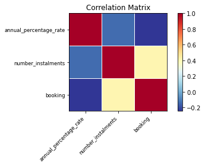

```python
corr = df.set_index("uuid").corr()
sm.graphics.plot_corr(corr, xnames = list(corr.columns))
plt.show()
```

Podemos observar que la mayor correlación parece existir entre 'booking' y 'number_instalments', pero es solo de 0.417031.

El P valor es el valor de probabilidad de que la correlación entre estas dos variables sea estadísticamente significativa. Si el nivel de significancia de 0.05, significa que estamos 95% seguros de que la correlación entre las variables es significativa.

Vamos a calcular el P valor:

```python
pearson_coef, p_value = stats.pearsonr(df['booking'], df['number_instalments'])
print("El coeficiente de correlación Pearson is", pearson_coef, " con un P valor de P =", p_value)
```

```
El coeficiente de correlación Pearson is 0.41703061400614677  con un P valor de P = 0.0
```

*Podemos determinar que, dado que el valor p es <0.001, la correlación entre la distancia entre 'booking' (el importe) y 'number_instalments" es estadísticamente significativa, aunque la relación lineal no es extremadamente fuerte (~ 0.417).*

```
(-1.2000000000000002, 25.2)
```

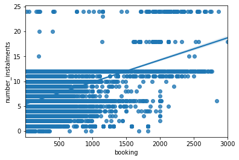

```python
sns.regplot(x="booking", y="number_instalments", data=df)
plt.ylim()
```

Siguiendo con las variables con una gran cantidad de valores nulos, con más de un 60% de valores nulos no nos van a aportar información por lo que vamos a eliminarlas.

```python
for variable in df.columns:
    x = pd.isnull(df[variable]).sum() > len(df[variable])*0.6
    if x == True:
        df = df.drop([variable], axis = 1)
```

Volvemos a ver cuántas variables tenemos ahora en nuestro dataframe:

```python
df.info()
```

```
<class 'pandas.core.frame.DataFrame'>
Int64Index: 32244 entries, 0 to 30287
Data columns (total 7 columns):
 #   Column                  Non-Null Count  Dtype
---  ------                  --------------  -----
 0   uuid                    32244 non-null  object
 1   merchant_uuid           30288 non-null  object
 2   created                 30288 non-null  datetime64[ns]
 3   country                 30288 non-null  object
 4   annual_percentage_rate  30288 non-null  float64
 5   number_instalments      30288 non-null  float64
 6   booking                 30288 non-null  float64
dtypes: datetime64[ns](1), float64(3), object(3)
memory usage: 2.0+ MB
```

Ahora solo tenemos 7 variables. Observamos los valores únicos de nuestra variable 'country':

```python
df.country.unique()
```

```
array([nan, 'Spain'], dtype=object)
```

```python
df = df.drop(['country'], axis = 1)
```

```python
df.info()
```

```
<class 'pandas.core.frame.DataFrame'>
Int64Index: 32244 entries, 0 to 30287
Data columns (total 6 columns):
 #   Column                  Non-Null Count  Dtype
---  ------                  --------------  -----
 0   uuid                    32244 non-null  object
 1   merchant_uuid           30288 non-null  object
 2   created                 30288 non-null  datetime64[ns]
 3   annual_percentage_rate  30288 non-null  float64
 4   number_instalments      30288 non-null  float64
 5   booking                 30288 non-null  float64
dtypes: datetime64[ns](1), float64(3), object(2)
memory usage: 1.7+ MB
```

Ahora ya tenemos solo 6 variables.

Como, exepto 'uuid', el resto de variables tienen algunos datos nulos, vamos a proceder a estudiarlas. Esta variable no tiene nulos y está compuesta por datos alfanuméricos.

Observamos que hay otra variable llamada 'merchant_uuid'. Vamos a ver si los valores son los mismos:

```python
df.describe(include=['object'])
```

|  | uuid | merchant_uuid |
| --- | --- | --- |
| count | 32244 | 30288 |
| unique | 32244 | 547 |
| top | 65942366af0a4706bb420896670e1c17 | 513f1c5b8be0415497902ee716840403 |
| freq | 1 | 6358 |

No, en el caso de 'merchant_uuid' vemos que hay 547 valores diferentes, mientras que uuid son valores únicos.

Vamos a hacer un **pequeño resumen** de las variables que hemos visto hasta ahora.

'uuid' y 'merchant_uuid' tienen valores alfanuméricos. Parece que uuid identifica a cada préstamo y sin embargo "merchant_uuid" relaciona algunos con otros, por lo que se trata del vendedor o comercial.

Por otro lado, 'created' es la fecha de creación (2018).

'annual_percentage_rate' es la tasa de porcentaje anual. Hay algo que llama la atención de esta variable, y es que cuando hemos visto sus estadísticas, el 3 quartil era 24.5, lo que es un valor dentro de lo común. Sin embargo, vemos que el valor máximo es de 315.949970, lo que no tiene ningún sentido al tratarse de una tasa. Debemos tener en cuenta, además, que, *según el Portal del Banco de España* la el tipo de interés legal en 2018 en España se situaba en un 3%, como puede apreciarse en el siguiente enlace:

https://clientebancario.bde.es/pcb/es/menu-horizontal/productosservici/relacionados/tiposinteres/guia-textual/tiposinteresrefe/Tabla_tipos_de_interes_legal.html

'number_instalments' es el número de plazos, cuyo máximo hemos visto anteriormente que era 24.

'booking' es el importe del préstamo.

'industry_name', que es una variable que hemos borrado, nos daba información acerca del sector del producto financiado. Lamentablemente, tenía tal cantidad de datos ausentes que no nos aportaba información relevante.

Por lo tanto, estamos analizando datos financieros de préstamos. Por los importes y plazos, no podemos hablar de préstamos hipotecarios si no que parecen créditos al consumo.

Dado que tenemos valores nulos en casi todas las variables, podríamos imputar los valores a la moda o a la media. Sin embargo, una cosa que llama la atención es que las observaciones que tienen todos (excepto 'uuid') sus valores nulos, son las mismas. Es decir, que no nos sirve imputar esos valores puesto que tendríamos que imputar todos los valores de la fila, salvo 'uuid', y la información perdería su sentido.

Por lo tanto **decidimos eliminar las filas que tengan más de 5 valores nulos.**

```python
# Eliminamos las filas que tengan más de 5 valores nulos:

df1 = df.dropna(thresh=5)
df1
```

|  | uuid | merchant_uuid | created | annual_percentage_rate | number_instalments | booking |
| --- | --- | --- | --- | --- | --- | --- |
| 0 | 69104dd917474265a25d2ea0b71a9445 | be7d7febda224ff492b12232cd7ad1f0 | 2018-01-01 01:22:28.959780 | 24.5 | 1.0 | 1000.00 |
| 1 | 84c593405aa145da93de781266103eea | 4350a1412c2e4dd78d36224d9ab78598 | 2018-01-01 06:38:55.516623 | 24.5 | 12.0 | 224.03 |
| 2 | 44f66d51e46441f6be393caff6e3ba1a | ad9e0106c88f4fc2b77a54ac3dfac954 | 2018-01-01 08:21:45.401655 | 24.5 | 12.0 | 69.90 |
| 3 | d00c1699becc4ac0b2af7741923d33d9 | f43a67a66d6f42779459fff92bc713e9 | 2018-01-01 09:40:03.977784 | 24.5 | 2.0 | 111.99 |
| 4 | 7ec194425c6a49919f38b5064183da1f | dadfda2ead7448ea83d181f3fd9ffb07 | 2018-01-01 09:50:55.992350 | 24.5 | 3.0 | 100.57 |
| ... | ... | ... | ... | ... | ... | ... |
| 30283 | 52f6f0f383aa4080aeb299369aaf7113 | 0ae5fc80ad2a4f70b7cf4c29d783585d | 2018-12-31 22:55:03.448879 | 24.5 | 12.0 | 386.72 |
| 30284 | c6219d2a5c184fdf905ed758b22421ae | 776b630e228e499c83b66f8f0ddaab18 | 2018-12-31 23:38:17.642972 | 0.0 | 6.0 | 266.81 |
| 30285 | b3aa52d40e894044b852c3c3dd08d809 | 776b630e228e499c83b66f8f0ddaab18 | 2018-12-31 23:44:55.284819 | 0.0 | 6.0 | 187.67 |
| 30286 | 9653098097234cbb9a649ea97629121f | ad9e0106c88f4fc2b77a54ac3dfac954 | 2018-12-31 23:51:14.109541 | 24.5 | 4.0 | 71.32 |
| 30287 | 0c126fc2046c4eaea520ce9b113da954 | 776b630e228e499c83b66f8f0ddaab18 | 2018-12-31 23:53:17.650640 | 0.0 | 6.0 | 142.20 |

30288 rows × 6 columns

Ahora nuestro dataframe se ha reducido a 6 columnas y 30.288 filas. Comprobemos que ya no tenemos valores nulos:

```python
df1.isnull().sum()
```

```
uuid                      0
merchant_uuid             0
created                   0
annual_percentage_rate    0
number_instalments        0
booking                   0
dtype: int64
```

Efectivamente, los valores nulos se concentraban en las mismas filas por lo que no ha sido necesario imputar valores a esos datos faltantes.

Volvamos a observar los valores de la variable 'annual_percentage_rate':

```python
df = df1
```

```python
df.annual_percentage_rate.max()
```

```
315.94997034161
```

El máximo es de 315.95, lo que no tendría sentido. Veámosla representada en una caja de bigotes:

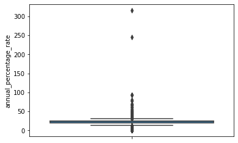

```python
sns.boxplot(y="annual_percentage_rate", data=df)
```

Efectivamente, vemos que hay outliers, por lo que vamos a imputar la media a todos aquellos valores que sean mayores de 100, ya que consideramos que se trata de un error.

```python
df2 = df[df["annual_percentage_rate"] > 100]
```

```python
df2
```

|  | uuid | merchant_uuid | created | annual_percentage_rate | number_instalments | booking |
| --- | --- | --- | --- | --- | --- | --- |
| 9449 | df2a862bb17d4df38c6afc93e9837b89 | 513f1c5b8be0415497902ee716840403 | 2018-06-15 07:52:11.057124 | 244.826455 | 6.0 | 172.68 |
| 10125 | dbde4bbd9ce44114b914e5da0cd69d87 | adca10cf13924be890c9d616cbc4a4e6 | 2018-06-27 23:22:17.571079 | 315.949970 | 1.0 | 134.68 |

Vemos que son solo dos observaciones, la 9.449 y la 10.125. Sustituyamos los valores de esas variables en esas dos filas por la media:

```python
media_rate = df.annual_percentage_rate.mean()
df.annual_percentage_rate[9449] = media_rate
df.annual_percentage_rate[10125] = media_rate

df.annual_percentage_rate.max()
```

```
92.9396291319141
```

Ya tendríamos corregidos esos dos valores erroneos.

### 2. Realiza un scatter plot en el que se compare el volumen financiado en un crédito con el número de cuotas elegido (number_instalments). ¿Qué se observa?

Vamos a realizar un scatter plot entre booking y number_instalments.

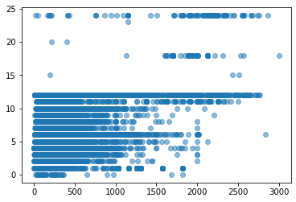

```python
plt.scatter( df.booking, df.number_instalments, alpha = 0.5)
plt.show()
```

Observamos que contra mayor es el volumen del préstamo, el número de cuotas también se incrementa. Además se aprecia que a partir de 12 cuotas, el número de cuotas es de 15, 18, 20 o 24 meses, algo habitual a la hora de realizar financiaciones.

### 3. ¿Cómo ha evolucionado el número de créditos concedidos a lo largo del año 2018? ¿Y el volumen prestado?

Primero vamos a ver el número de créditos concedidos a lo largo del 2018:

```python
df.groupby(df['created'].dt.strftime('%m'))['booking'].count()
```

```
created
01    1924
02    1725
03    1406
04    1628
05    1917
06    1717
07    1989
08    2404
09    3200
10    3683
11    4597
12    4098
Name: booking, dtype: int64
```

Y para verlo gráficamente con un diagrama de barras:

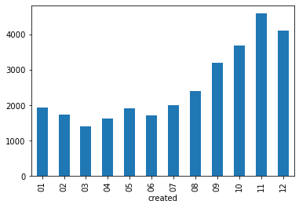

```python
df.groupby(df['created'].dt.strftime('%m'))['booking'].count().plot(kind='bar')
```

Observamos que el año comenzó en descenso obteniendo el mínimo de préstamos concedidos en marzo y luego hubo una evolución ascendente con un ligero descenso en junio y en diciembre.

Vamos a ver el importe total prestado cada mes, ordenado por volumen de menos a mayor. Observamos que los meses en los que ha habido más financiaciones han sido diciembre, noviembre, septiembre y octubre.

```python
df.groupby(df['created'].dt.strftime('%B'))['booking'].sum().sort_values()
```

```
created
March        3.567061e+05
February     4.354946e+05
April        4.501701e+05
January      4.772110e+05
May          5.470625e+05
June         5.520928e+05
July         6.398403e+05
August       8.165891e+05
December     1.149154e+06
November     1.240101e+06
September    1.304327e+06
October      1.313809e+06
Name: booking, dtype: float64
```

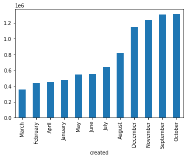

```python
df.groupby(df['created'].dt.strftime('%B'))['booking'].sum().sort_values().plot(kind= 'bar')
```

```python
df.sort_values(['booking'],ascending=False).groupby('created').head(12)
```

|  | uuid | merchant_uuid | created | annual_percentage_rate | number_instalments | booking |
| --- | --- | --- | --- | --- | --- | --- |
| 13767 | ff5e26cd3c904eb6bda9a1932cb0713d | 7d9ba35904ef4552a356a2f0f93869c3 | 2018-08-22 14:40:49.656284 | 0.000000 | 18.0 | 3000.00 |
| 15975 | f86ccf4b606b49b783c419df316df761 | 085d07df19a14ea28a2a923bcb6c323a | 2018-09-12 15:03:49.292607 | 12.000000 | 24.0 | 2865.93 |
| 8908 | e0fcefeb3f324e60bbfe82ea3565107d | 5657e99f1c6249d2b8f1f0c303fad9bf | 2018-06-06 14:38:44.530254 | 20.000000 | 6.0 | 2840.89 |
| 7566 | ee6d817ad96d433092b19a72897a952b | 085d07df19a14ea28a2a923bcb6c323a | 2018-05-17 13:58:31.781032 | -0.000003 | 12.0 | 2769.23 |
| 18350 | aee7246640ad444ab7d8d916db9c3123 | 5657e99f1c6249d2b8f1f0c303fad9bf | 2018-10-04 13:53:36.984052 | 12.000000 | 24.0 | 2760.42 |
| ... | ... | ... | ... | ... | ... | ... |
| 28633 | faa6c44f368b40868c0a30df97697e62 | a96dd7d6b3bf477a8317de31357e1692 | 2018-12-18 14:29:37.347036 | 24.500000 | 2.0 | 0.66 |
| 9681 | cdbfeebbefa9405db1554e376e4f83e5 | 94a84d2b32a04657b39048f1c3e887c7 | 2018-06-19 15:53:04.535414 | 24.500000 | 4.0 | 0.66 |
| 9685 | 64f1cd2d03124cb988ffd8648e291ce0 | 94a84d2b32a04657b39048f1c3e887c7 | 2018-06-19 16:22:48.098905 | 24.500000 | 4.0 | 0.66 |
| 2165 | 1a8cbeffa49d45ebbf2e29604dd9e475 | 10997d1d7a784bfd8d28c3f040a7340b | 2018-02-05 15:51:15.184447 | 24.500000 | 4.0 | 0.61 |
| 2856 | 3e3a65690c644bf5aa19f06cb3d53877 | 60987200a57641909c37320b5b7d5e95 | 2018-02-16 09:25:12.849120 | -0.000004 | 4.0 | 0.53 |

30288 rows × 6 columns

### 4. Trata de obtener algún insight interesante del dataset y realiza una explicación detallada, apoyándote de las métricas y las representaciones grácas que sean necesarias.

Vamos a agrupar los datos por vendedor para ver en orden descendente quién es el vendedor que ha dado importes superiores de préstamos:

```python
df.sort_values(['booking'],ascending=False).groupby('merchant_uuid').head()
```

|  | uuid | merchant_uuid | created | annual_percentage_rate | number_instalments | booking |
| --- | --- | --- | --- | --- | --- | --- |
| 13767 | ff5e26cd3c904eb6bda9a1932cb0713d | 7d9ba35904ef4552a356a2f0f93869c3 | 2018-08-22 14:40:49.656284 | 0.000000 | 18.0 | 3000.00 |
| 15975 | f86ccf4b606b49b783c419df316df761 | 085d07df19a14ea28a2a923bcb6c323a | 2018-09-12 15:03:49.292607 | 12.000000 | 24.0 | 2865.93 |
| 8908 | e0fcefeb3f324e60bbfe82ea3565107d | 5657e99f1c6249d2b8f1f0c303fad9bf | 2018-06-06 14:38:44.530254 | 20.000000 | 6.0 | 2840.89 |
| 7566 | ee6d817ad96d433092b19a72897a952b | 085d07df19a14ea28a2a923bcb6c323a | 2018-05-17 13:58:31.781032 | -0.000003 | 12.0 | 2769.23 |
| 18350 | aee7246640ad444ab7d8d916db9c3123 | 5657e99f1c6249d2b8f1f0c303fad9bf | 2018-10-04 13:53:36.984052 | 12.000000 | 24.0 | 2760.42 |
| ... | ... | ... | ... | ... | ... | ... |
| 2796 | 0d96638833af43ca88fb1667c3d966e3 | 80c4cf19f2b845f4939105144500ec18 | 2018-02-15 09:15:41.821440 | 24.500000 | 1.0 | 0.74 |
| 9686 | f1ee9791710d4fc088a9cb924c812023 | 94a84d2b32a04657b39048f1c3e887c7 | 2018-06-19 16:23:03.912481 | 24.500000 | 4.0 | 0.66 |
| 28633 | faa6c44f368b40868c0a30df97697e62 | a96dd7d6b3bf477a8317de31357e1692 | 2018-12-18 14:29:37.347036 | 24.500000 | 2.0 | 0.66 |
| 9681 | cdbfeebbefa9405db1554e376e4f83e5 | 94a84d2b32a04657b39048f1c3e887c7 | 2018-06-19 15:53:04.535414 | 24.500000 | 4.0 | 0.66 |
| 2165 | 1a8cbeffa49d45ebbf2e29604dd9e475 | 10997d1d7a784bfd8d28c3f040a7340b | 2018-02-05 15:51:15.184447 | 24.500000 | 4.0 | 0.61 |

1876 rows × 6 columns

El vendedor con código '7d9ba35904ef4552a356a2f0f93869c3' ha sido el vendedor en dar el préstamo de mayor importe.

Queremos saber quienes han sido los 5 vendedores que han dado los mayores importes de préstamos en global, es decir, la mayor cantidad de dinero:

```python
df4 = df.groupby(['merchant_uuid'])['booking'].sum()
```

```python
df4.sort_values(ascending=False).head(5)
```

```
merchant_uuid
513f1c5b8be0415497902ee716840403    1643289.44
776b630e228e499c83b66f8f0ddaab18    1360521.28
a3cb9f48879c436782aceeed2e921ec4     428342.73
7d9ba35904ef4552a356a2f0f93869c3     423189.25
5657e99f1c6249d2b8f1f0c303fad9bf     405462.91
Name: booking, dtype: float64
```

El vendedor '513f1c5b8be0415497902ee716840403' ha sido el que ha dado el mayor importe de préstamos con un total de 1643289.44.

Vemos también que el vendedor '7d9ba35904ef4552a356a2f0f93869c3', que era el que había dado el préstamo más alto (3000), está en el 4º puesto con respecto al mayor importe total.